## Question

Go through the book “R for Beginners” if you are not familiar with R programming

## Answer

作为一名R语言初学者，对“R for Beginners”进行阅读，并进行简单总结。

1、R的功能与特点：

（a）功能：统计分析、绘图。

（b）特点：解释型语言，无需编写完整程序，输入命令后可直接执行。有着很好的数据可视化效果。

2、基本原理与基本使用规则：

（a）R中所有变量、数据、函数、结果均以对象形式存储在内存中，操作本质是对对象的运算。

（b）函数带“()”，无参数也需保留，如ls()。

（c）n <- 10，表示将10赋值给n。

（d）命名规则：以字母开头，可含数字、字母、.、_，对大小写敏感。

3、R的数据操作

（a）数据类型：数值型、字串型、逻辑型（默认输入的数字是double型）。

（b）本章节主要以实例展示对象的创建与使用。

4、R绘图

（a）本章通过绘图管理->绘图函数->参数设置->实例四部分，介绍了从基础图表到自定义图形的绘图全流程。

5、R的统计分析

（a）以关于方差分析的简单例子引出对R统计分析功能的系统介绍。

（b）介绍统计函数的核心参数————公式的含义。

（c）介绍能适配不同对象的“智能函数”————泛型函数

6、编程实践

（a）介绍高效处理数据的方式：循环和向量化以及apply家族函数

（b）介绍自定义函数

通过“R for Beginners”的学习，对R整体有一定了解，关于各个对象、函数等目前仅以阅读为主，需要通过后续的课程学习、作业来加强实际编程能力。

## Question

Use knitr to produce at at least 3 examples where text is mixed with figures, tables and mathematical formulas.

## Answer

### Example 1: K-means聚类模型分析

在运筹优化领域经常会面临处理大规模数据的情况，如果不对数据进行处理，算法运行往往会出现大量不必要的操作，因此可以依据特征对数据进行聚类操作，节省运行效率。

#### 1.1 生成随机数据集

生成含4个簇的三维数据集，用于K-means聚类。

K-means聚类数据集（前10行，三维特征）

| x | y | z |
| --- | --- | --- |
| 2.3709584 | 2.2009654 | -1.0009292 |
| 0.4353018 | 2.0447511 | 1.3337772 |
| 1.3631284 | -0.0032086 | 2.1713251 |
| 1.6328626 | 2.8484819 | 3.0595392 |
| 1.4042683 | 0.3332266 | -0.3768616 |
| 0.8938755 | 1.1055138 | -0.1508556 |
| 2.5115220 | 0.5777441 | 0.2941786 |
| 0.9053410 | 0.8776498 | -0.0540558 |
| 3.0184237 | 1.1881930 | 0.3542563 |
| 0.9372859 | 1.1191610 | 0.8146220 |

#### 1.2 公式

K-means的WCSS公式如下：
$$\text{WCSS} = \sum_{k=1}^{K} \sum_{x \in C_k} \| x - \mu_k \|^2$$

$$其中，K表示簇的个数；C_{k}表示第k个簇的所有样本；x表示单个样本的坐标；μ_{k}表示第k个簇的中心；$$
$$目标是最小化样本到簇中心的“距离平方和”最小，WCSS越小，表示簇越紧凑。$$

#### 1.3 结果分析

##### 1.3.1 模型系数

各簇样本数量分布

| 簇标签 | 样本数 |
| --- | --- |
| 1 | 100 |
| 2 | 102 |
| 3 | 100 |
| 4 | 98 |

K-means组内平方和（WCSS）统计

| 指标 | 数值 |
| --- | --- |
| 总WCSS | 1182.92 |
| 簇1 WCSS | 278.05 |
| 簇2 WCSS | 306.85 |
| 簇3 WCSS | 290.94 |
| 簇4 WCSS | 307.09 |

4个簇的中心坐标（三维特征均值）

| x中心 | y中心 | z中心 | 簇标签 |
| --- | --- | --- | --- |
| 5.913253 | 6.8307085 | 3.061457 | 1 |
| 1.043639 | 0.8964532 | 1.042473 | 2 |
| 2.032936 | 4.8821695 | 8.002363 | 3 |
| 5.155315 | 0.8867034 | 3.026837 | 4 |

##### 1.3.2 拟合图像

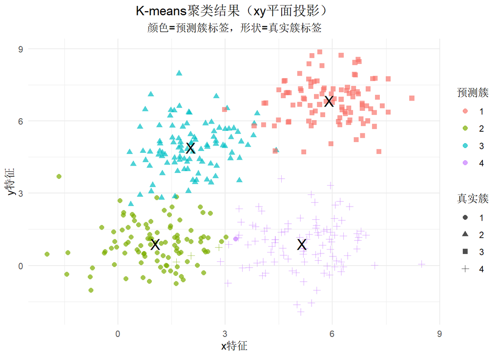

### Example 2: 线性规划问题

#### 2.1 问题描述

本实例是一个运筹优化领域中的线性规划问题： 某公司生产两种产品，生产1个产品A需要消耗1个单位的资源、2个小时的人力，利润8万元；生产1个产品B需要消耗3个单位的资源、1个小时的人力，利润9万元；资源总量45单位，人力总工时最多52小时。

$$\max Z = 8x + 9y$$

$$x + 3y \leq 45 \quad \text{（机器时间约束）} \\
2x + y \leq 52 \quad \text{（人工时间约束）} \\
x \geq 0,\ y \geq 0 \quad \text{（非负约束，产量不能为负）}$$

#### 2.2 调用IpSolve求解

```
## 最优解状态： 0 (0表示找到最优解)
```

```
## 最大利润： 246 元
```

```
## 产品A的最优产量： 22.2 单位
```

```
## 产品B的最优产量： 7.6 单位
```

#### 2.3 结果分析

根据实际资源约束确定可解解范围，调用求解器求解最优解。

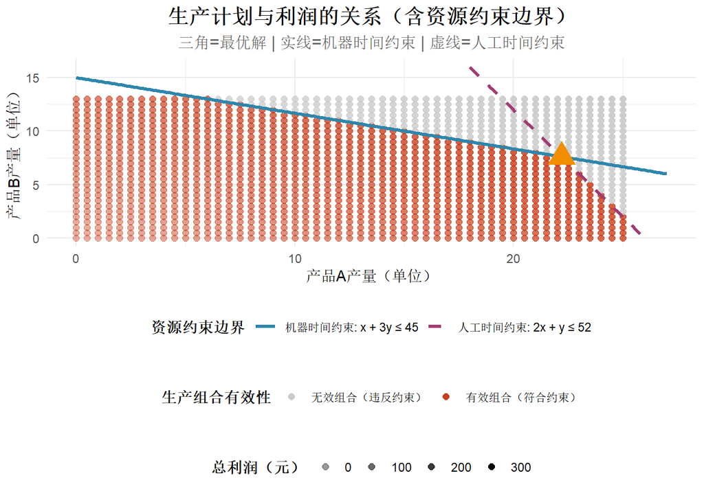

### Example 3: 中心极限定理验证

中心极限定理：无论总体服从何种分布，当样本量足够大时，样本均值的抽样分布会趋近于正态分布。

#### 3.1 生成随机数据

样本均值的理论正态分布参数

| Distribution | Mean | SD |
| --- | --- | --- |
| Uniform(0,1) | 0.5 | 0.0527046 |
| Exponential(1) | 1.0 | 0.1825742 |
| Binomial(10,0.3) | 3.0 | 0.2645751 |

#### 3.3 结果分析

根据图像展示，尽管原始数据总体不是正态分布，但是样本均值的分布与理论正态分布高度吻合，验证了结论。

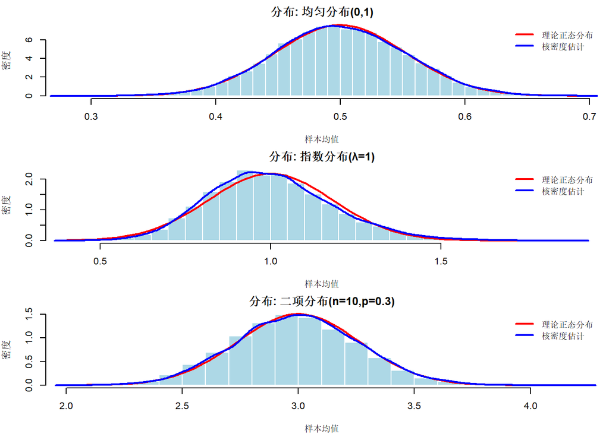